# 02-SAS PROC FREQ

David Henderson

6 September 2018

```r
library(here)
library(knitr)
```

# Teamwork!

We got out teams for the hackathon yesterday and I have been paired up with Sumeet Kalia from the University of Toronto.

I shared the cleaning files that I had prepared already and Sumeet has got back to me with output from SAS that was run with pre-processed files I created.

## SAS PROC FREQ output

Here is the output from the PROC FREQ he ran in SAS on the cleaned dataset

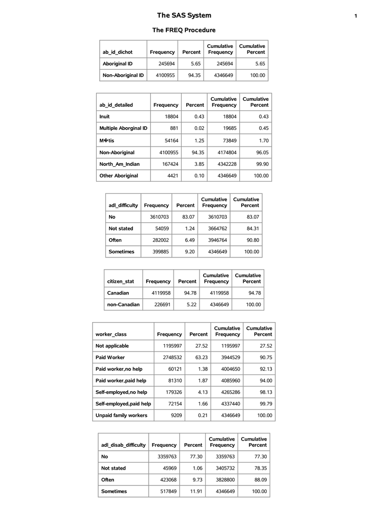

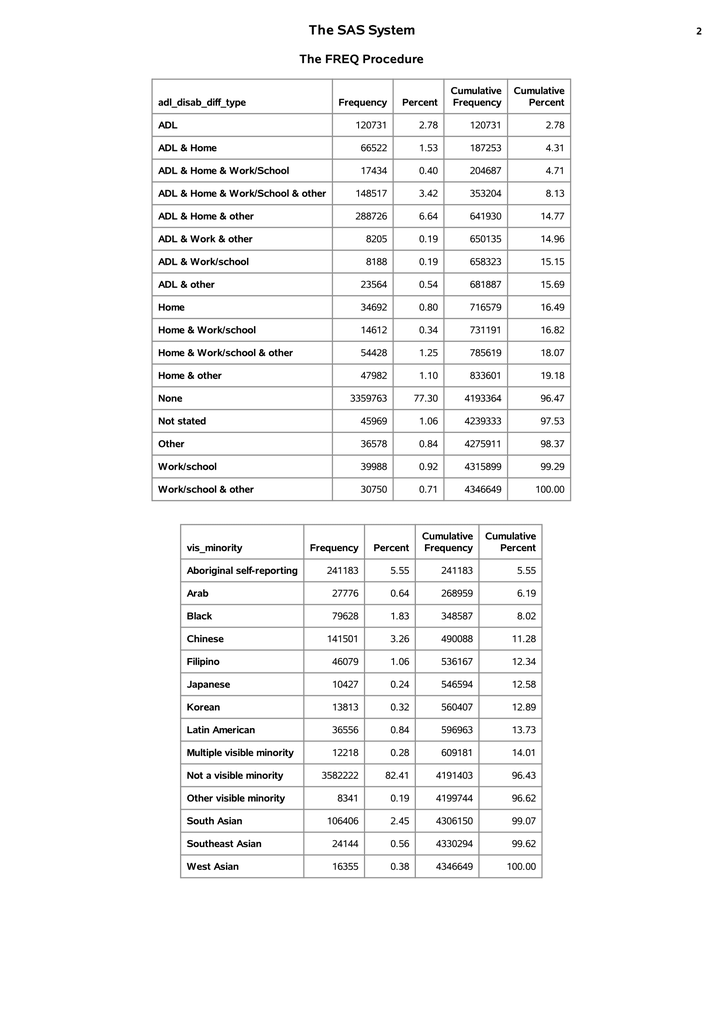

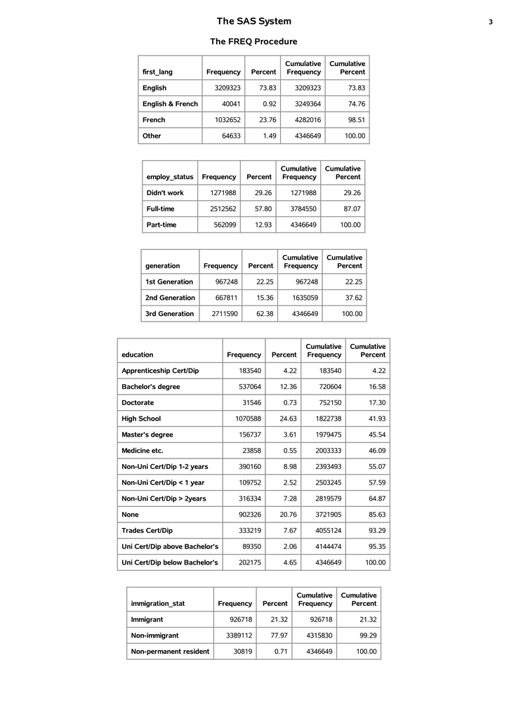

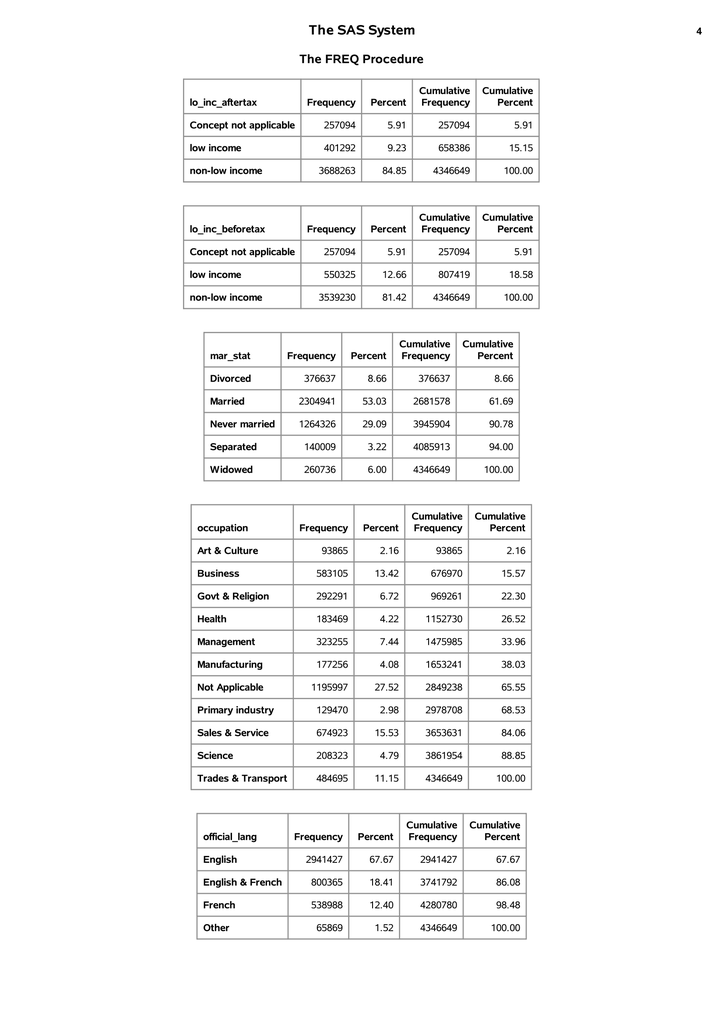

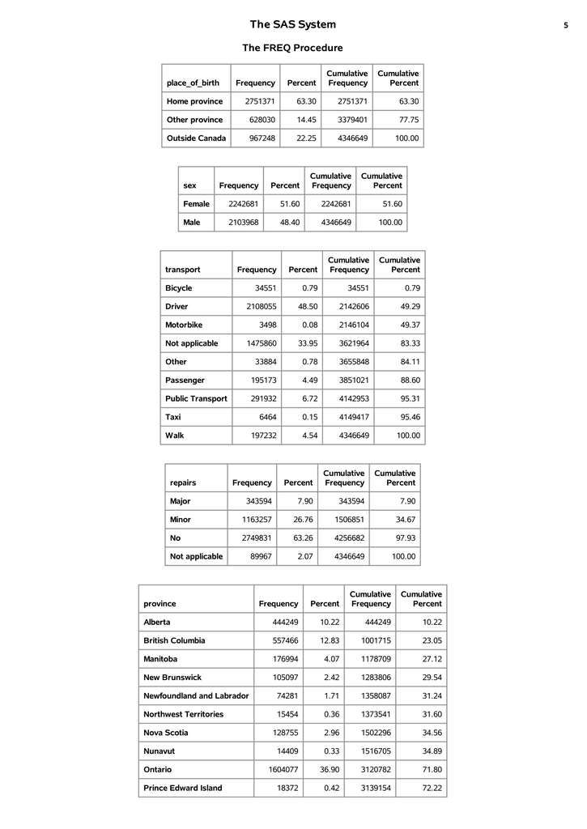

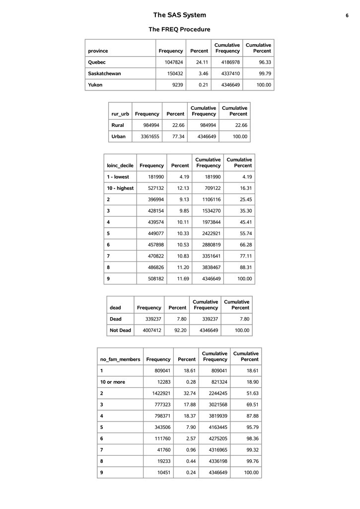

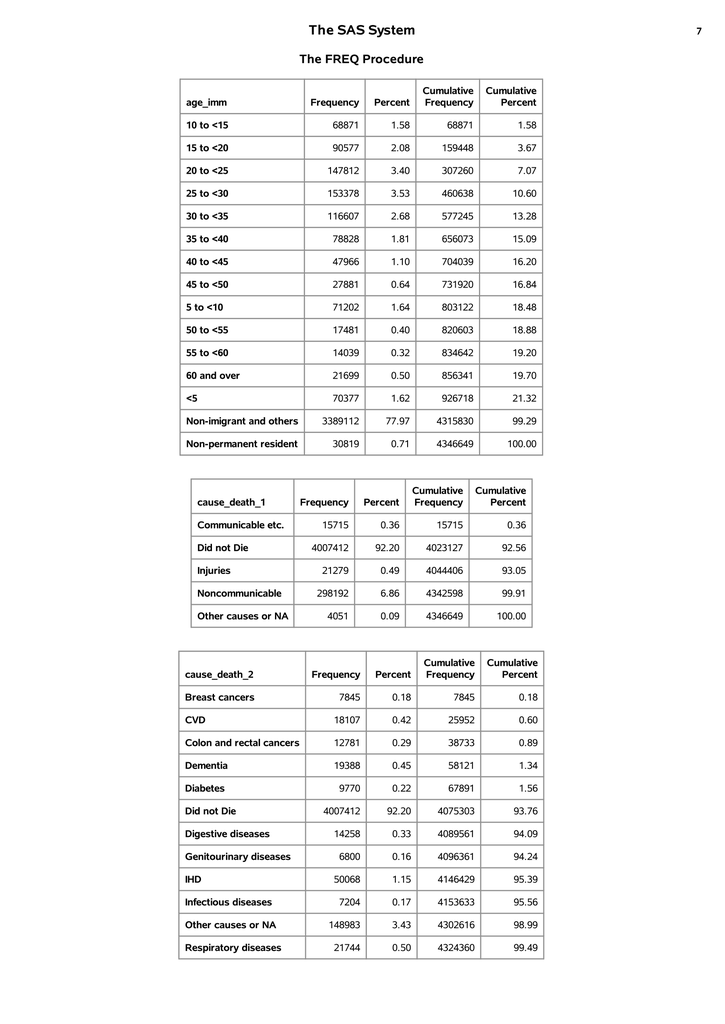

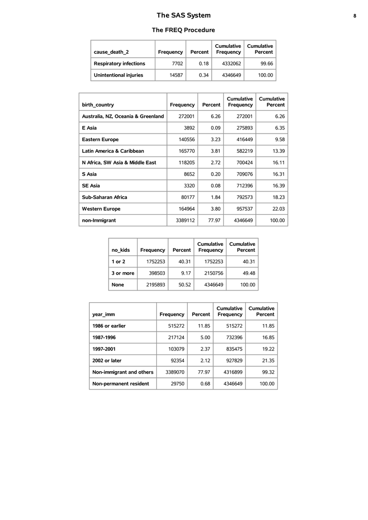

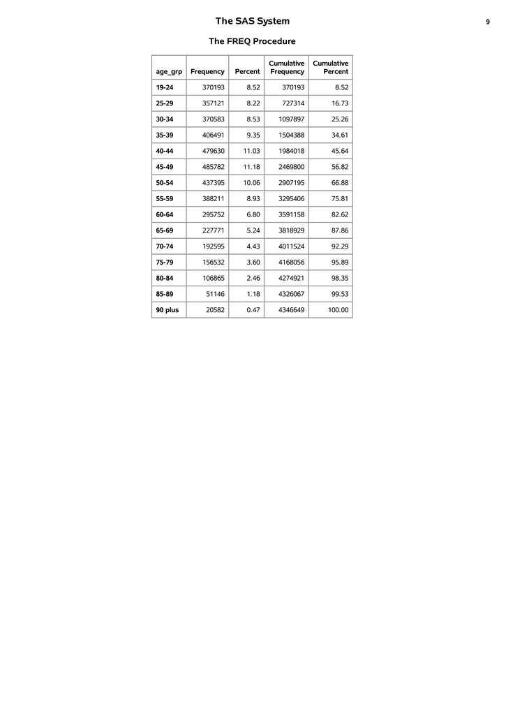

## Initial thoughts from Sumeet

Based on the potential questions provided by the Hackathon organisers

1. What socioeconomic factors contribute to the greatest inequalities in mortality?
1. Mortality is a binary outcome 92% alive only 8% dead
2. Socioecnomic factors could be categorical predictors, income decile etc.
3. Logistic regression is a possibility but because of rare outcome this may over or under estimate the true standard errorsof the regression coefficients [^1] [^2]
4. Perhaps a log-binomial model would be better…
2. Does the healthy immigrant advantage extend to the second generation?
1. 1st, 2nd, 3rd generation can be considered as ordinal
2. Propotional odds model based on identified covariates?
3. Does the risk of cardiovascular mortality vary among immigrants from different source countries?
1. Using `death_cause-2` variable we can see that only 18,107 indivudals (0.42%) died from CVD - very small proportion of 4.34 million
2. Maybe we should examine the distribution of ethnicity of patients who died due to CVD with patients who are alive (92%) or patients who did die but not due to CVD (7.4%).

Generally - Shape file might be handy to plot adjusted probabilities from logistic/log-binomial or ordinal prop.odds models at the province level and then use colour gradient to plot on the map.

[^1]: Barros AJ, Hirakata VN, [Alternatives for logistic regression in cross-sectional studies: an empirical comparison of models that directly estimate the prevalence ratio.](https://bmcmedresmethodol.biomedcentral.com/articles/10.1186/1471-2288-3-21) BMC Med Res Methodol. 2003 Oct; 3:21
[^2]: Greenland S. [Model-based estimates of relative risks and other epidemiologic measures in studies of common outcomes and in case-control studies.](https://academic.oup.com/aje/article/160/4/301/165918) Am J Epidemiol. 2004 Aig; 160(4):301-5